# Más allá de los gradientes socioeconómicos

Seguridad económica subjetiva, heterogeneidad residual y configuraciones de amenaza

[Gonzalo Torres Rosales](https://gonzalotr11.github.io/)

go.torres@uc.cl

Instituto de Sociología, Pontificia Universidad Católica de Chile

Cristóbal Cabezas

2026-09-20

## Punto de partida

Problema

Los gradientes socioeconómicos muestran diferencias promedio en salud mental, pero dejan abierta una pregunta: ¿por qué personas en posiciones observadas similares reportan niveles tan distintos de malestar?

Posición objetiva  
ingreso, educación, vivienda, empleo

→

Evaluación de seguridad  
protección, amenaza, presión

→

Malestar psicológico  
PHQ-4

Idea central: los determinantes sociales son una buena manera gruesa de captar la desigualdad de respuestas de las personas ante su entorno, pero no logran dar cuenta de cómo se traducen de manera heterogénea en malestar.

## Marco teórico breve

### Determinantes sociales

La salud mental está socialmente estructurada por ingreso, empleo, vivienda, territorio, protección social y acceso a salud.

Alegría et al., 2023 · Kirkbride et al., 2024 · Lund et al., 2018

### Evaluación de amenaza

Una condición se vuelve psicológicamente relevante cuando se evalúa como exigente, incierta o superior a los recursos disponibles.

Lazarus & Folkman, 1984 · Folkman, 2013 · Biggs & Brough, 2025

### Inseguridad económica

La inseguridad incluye privación actual, riesgo futuro, protección insuficiente, deuda, presión financiera y dudas sobre recuperación.

Osberg, 2015 · Auger et al., 2024 · Simonse et al., 2024 · Samuel et al., 2025

La pregunta social-psicológica es qué riesgos y obligaciones son percibidos como manejables o potencialmente desestabilizadores.

## Lo que hace el paper inicial

01

### Gradiente objetivo

Se estima PHQ-4 a partir de una posición socioeconómica multidimensional.

02

### PHQ-4 esperado

El modelo produce una expectativa de malestar para cada perfil observado.

03

### Residual

Se calcula malestar observado menos malestar esperado.

04

### Seguridad subjetiva

Se evalúa si protección, amenaza, deuda y presión financiera distinguen esas desviaciones.

**Diseño:** EBS 2023 · adultos en Chile · PHQ-4 continuo · modelos lineales ponderados por diseño muestral · ponderador, estratos y UPM.

## Primer resultado: un gradiente objetivo incompleto

5.02%

variación ponderada de PHQ-4 explicada por el modelo objetivo expandido

**Modelo objetivo:** ingreso, educación, tenencia, etapa vida-laboral, sistema de salud, privación habitacional, inseguridad territorial, sexo y macrozona.

**Lectura:** hay gradiente, pero mucha dispersión alrededor de sus predicciones.

[figure not shown]

## Seguridad económica subjetiva

### Protección ante shocks

¿Puedo enfrentar un problema grave de salud o una emergencia económica?

### Amenaza futura

¿Es probable perder estabilidad laboral o ingresos?

### Presión presente

¿Puedo llegar a fin de mes con los recursos disponibles?

### Deuda

¿Las obligaciones financieras son manejables o ya tensionan la vida cotidiana?

La seguridad económica subjetiva condensa evaluaciones situadas de protección, amenaza y capacidad de respuesta.

## ¿Qué distingue el residual?

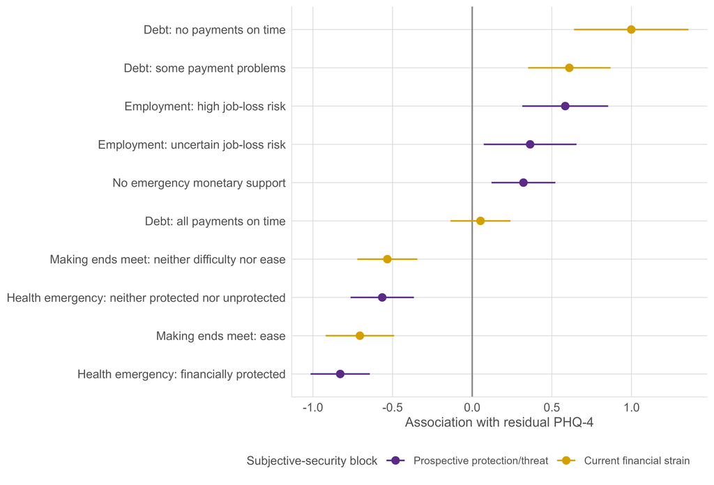

## Configuraciones esperado–residual

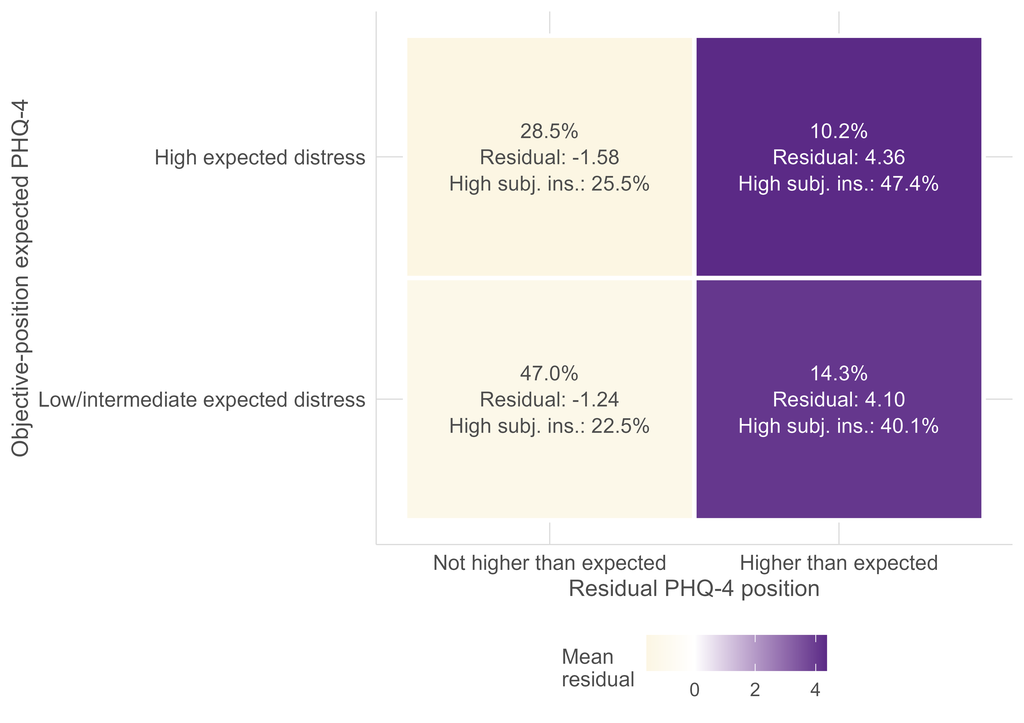

## Qué mostró el análisis inicial y qué deja abierto

### Resultado de base

La variación alrededor del gradiente se organiza por protección, amenaza, presión financiera y deuda.

### Pregunta que se abre

El análisis residual permite avanzar hacia mecanismos situados de amenaza y respuesta.

Giro para la expansión de la demostración

La siguiente etapa examina amenazas concretas, recursos disponibles y configuraciones que combinan vulnerabilidad y protección.

## Dos ejercicios: amenaza situada y recursos

Posición observada  
quintil, educación, empleo

→

Amenaza situada  
empleo y salud

+

Recursos funcionales  
recuperación y absorción

↔︎

PHQ-4  
estado emocional

### Ejercicio 1: trabajo

Amenaza de perder el empleo y recursos para recuperarse o absorber una emergencia.

### Ejercicio 2: salud

Protección frente a un shock de salud y apoyo monetario disponible ante una emergencia.

Pregunta: dentro de posiciones observadas comparables, ¿qué combinaciones de amenaza situada y recursos distinguen el malestar psicológico?

## Metodología del primer ejercicio laboral

Universo

Personas ocupadas con información válida sobre riesgo de perder el empleo, recursos funcionales y PHQ-4.

Configuración

3 niveles de amenaza laboral × 3 niveles de recursos disponibles.

Estimación

Medias PHQ-4 ajustadas con `survey::svyglm()`, ponderador, estratos y UPM.

Recursos funcionales

1. **Recuperación:** conocer a alguien que pueda ayudar a conseguir trabajo remunerado.
2. **Absorción:** conocer a alguien que pueda prestar dinero en una emergencia.
3. **Conteo:** ningún recurso, un recurso o ambos recursos.

## De 3 × 3 a perfiles de experiencia

Sin recursos

Un recurso

Ambos recursos

Amenaza baja

Baja / ninguno

Baja / uno

Baja / ambos

Amenaza incierta

Incierta / ninguno

Incierta / uno

Incierta / ambos

Amenaza alta

Alta / ninguno

Alta / uno

Alta / ambos

La categoría incierta se conserva porque no necesariamente es un punto medio ordinal: puede expresar ambigüedad real sobre la estabilidad futura.

## Primer ejercicio laboral: configuraciones dentro de quintiles

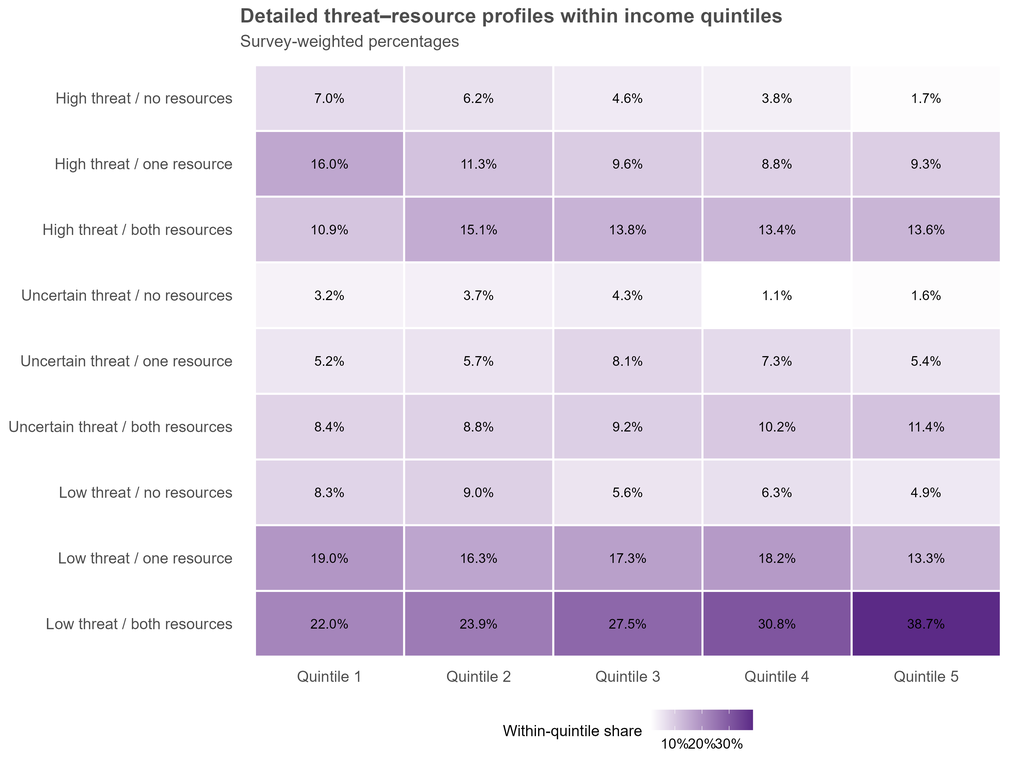

## Primer ejercicio laboral: PHQ-4 ajustado por configuración

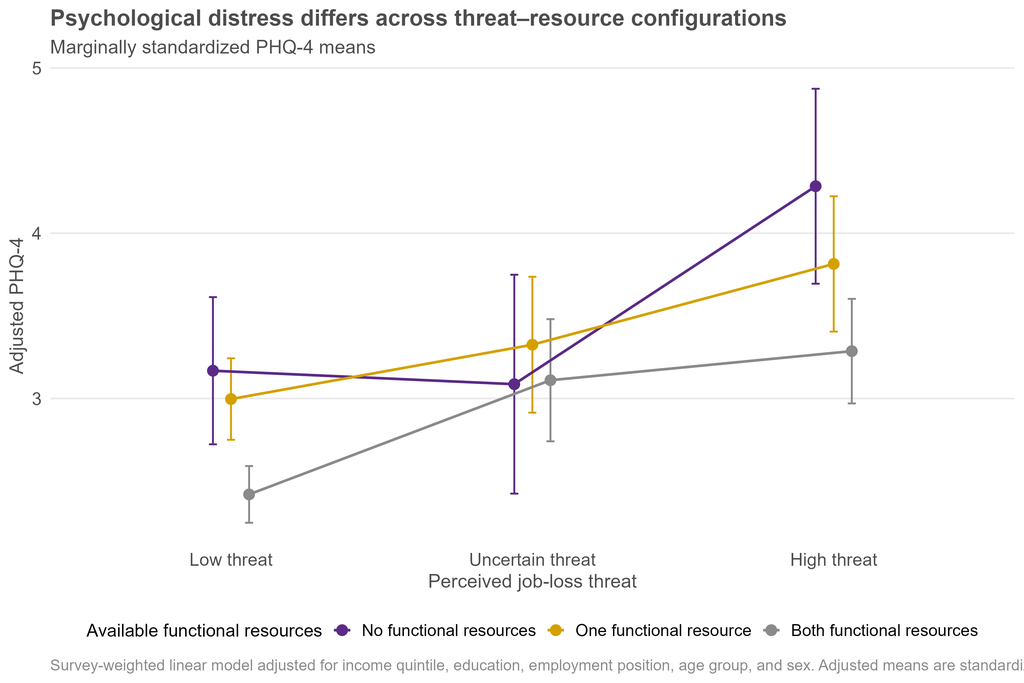

## Volver al residual: más o menos malestar del esperado

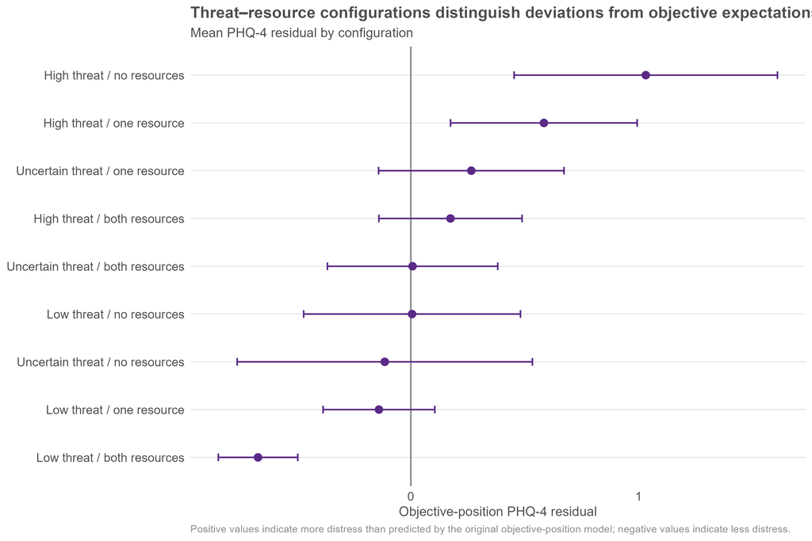

## Segundo ejercicio salud: perfiles dentro de quintiles

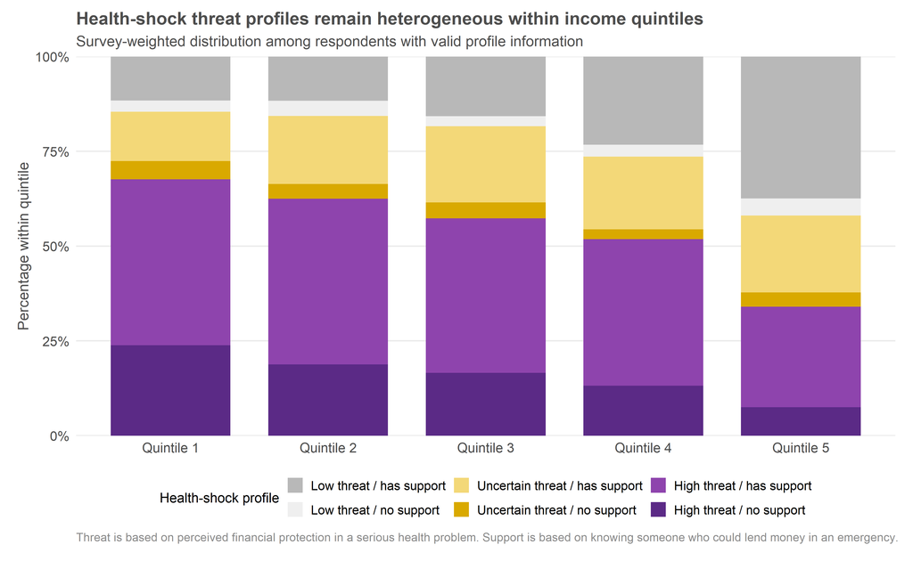

## Segundo ejercicio salud: mapa de configuraciones

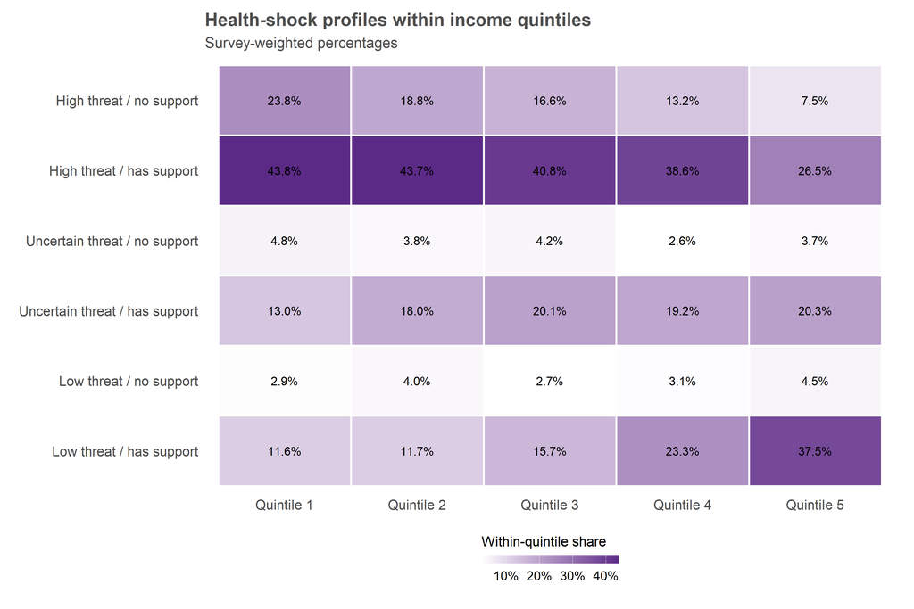

## Segundo ejercicio salud: residual por perfil

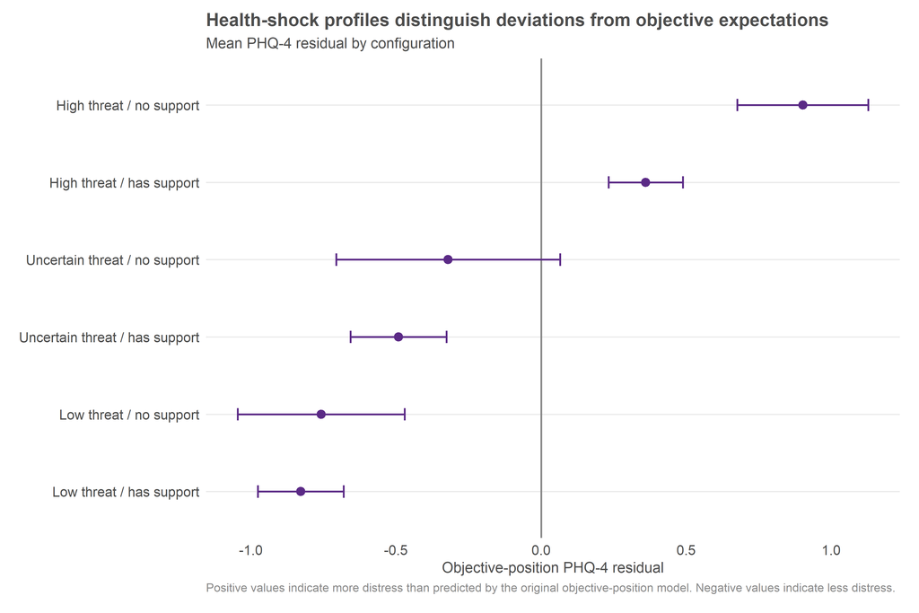

## Por qué estos resultados importan para el paper

### Menos malestar del esperado

Las configuraciones de baja amenaza y apoyo disponible se ubican por debajo del residual esperado.

### Más malestar del esperado

Las configuraciones de alta amenaza y apoyo ausente se ubican por encima de lo esperado por posición objetiva.

Nueva formulación

El residual comienza a adquirir contenido social como configuración de amenaza y recursos.

## Lectura de la recta final

### Resultado sólido

Las configuraciones amenaza–recursos distinguen PHQ-4 ajustado y residuales respecto del gradiente objetivo.

### Resultado prudente

Los ejercicios muestran acumulación y compensación asociacional dentro de posiciones observadas comparables.

La nueva etapa del análisis modela experiencias situadas de amenaza y capacidad de respuesta.

## Conclusión

Tesis

Los determinantes sociales siguen siendo el punto de partida, pero la experiencia psicológica de la desigualdad depende también de cómo las personas evalúan sus riesgos, obligaciones y capacidades de respuesta.

**1.** El gradiente objetivo existe, pero es incompleto.

**2.** La seguridad económica subjetiva ordena parte de la heterogeneidad residual.

**3.** Las configuraciones de amenaza y recursos muestran cómo especificar la heterogeneidad residual.

## Referencias breves

- Alegría, M., Alvarez, K., Cheng, M., & Falgas-Bague, I. (2023). Recent advances on social determinants of mental health. *American Journal of Psychiatry*.
- Auger, V., Sommet, N., & Normand, A. (2024). The Perceived Economic Scarcity Scale. *British Journal of Social Psychology*.
- Biggs, A., & Brough, P. (2025). Stress and coping theory. En *Handbook of Concepts in Health, Health Behavior and Environmental Health*.
- Kirkbride, J. B., et al. (2024). The social determinants of mental health and disorder. *World Psychiatry*.
- Lazarus, R. S., & Folkman, S. (1984). *Stress, appraisal, and coping*. Springer.
- Samuel, L. J., et al. (2025). Financial strain measures and associations with adult health. *Social Science & Medicine*.
- Simonse, O., Van Dijk, W. W., Van Dillen, L. F., & Van Dijk, E. (2024). Economic predictors of financial stress. *Journal of Behavioral and Experimental Finance*.
- Sterud, T., Lunde, L.-K., Berg, R., Proper, K. I., & Aanesen, F. (2025). Mental health effects of unemployment and re-employment. *Occupational and Environmental Medicine*.